# **Cardio Good Fitness Project - Linear Regression Analysis Of A Retail Store That Sells Treadmill Products - By David Salako.**

## Fixing the data types

- All variables that are integer are valid data types with the except of Fitness. Fitness is a subjective rating given by a customer for self-fitness on a scale of 1 to 5, it should be treated as a category data type.
- Product, Gender and Marital Status are each of the object data type; they can be converted to the category data type.

`coverting "objects" to "category" reduces the data space required to store the dataframe, eases computation and increases resource efficiency`

```python
CGFPdf["Product"]=CGFPdf["Product"].astype("category")
CGFPdf["Gender"]=CGFPdf["Gender"].astype("category")
CGFPdf["MaritalStatus"]=CGFPdf["MaritalStatus"].astype("category")
CGFPdf["Fitness"]=CGFPdf["Fitness"].astype("category")
```

```python
CGFPdf.info()
```

```
<class 'pandas.core.frame.DataFrame'>
RangeIndex: 180 entries, 0 to 179
Data columns (total 9 columns):
 #   Column         Non-Null Count  Dtype
---  ------         --------------  -----
 0   Product        180 non-null    category
 1   Age            180 non-null    int64
 2   Gender         180 non-null    category
 3   Education      180 non-null    int64
 4   MaritalStatus  180 non-null    category
 5   Usage          180 non-null    int64
 6   Fitness        180 non-null    category
 7   Income         180 non-null    int64
 8   Miles          180 non-null    int64
dtypes: category(4), int64(5)
memory usage: 8.3 KB
```

OBSERVATIONS ABOVE:

Product, Gender, Marital Status and Fitness have been converted to category data types.

`it is observed that the memory usage has decreased from 12.8KB to 8.3KB`

## Give a statistical summary for the dataset.

```python
CGFPdf.describe()
```

|  | Age | Education | Usage | Income | Miles |
| --- | --- | --- | --- | --- | --- |
| count | 180.000000 | 180.000000 | 180.000000 | 180.000000 | 180.000000 |
| mean | 28.788889 | 15.572222 | 3.455556 | 53719.577778 | 103.194444 |
| std | 6.943498 | 1.617055 | 1.084797 | 16506.684226 | 51.863605 |
| min | 18.000000 | 12.000000 | 2.000000 | 29562.000000 | 21.000000 |
| 25% | 24.000000 | 14.000000 | 3.000000 | 44058.750000 | 66.000000 |
| 50% | 26.000000 | 16.000000 | 3.000000 | 50596.500000 | 94.000000 |
| 75% | 33.000000 | 16.000000 | 4.000000 | 58668.000000 | 114.750000 |
| max | 50.000000 | 21.000000 | 7.000000 | 104581.000000 | 360.000000 |

```python
CGFPdf.describe(include=["category"])
```

|  | Product | Gender | MaritalStatus | Fitness |
| --- | --- | --- | --- | --- |
| count | 180 | 180 | 180 | 180 |
| unique | 3 | 2 | 2 | 5 |
| top | TM195 | Male | Partnered | 3 |
| freq | 80 | 104 | 107 | 97 |

### Check for missing values.

- Product has three types of treadmill models, TM195 being the most sold model.
- Males(104) have purchased most products compared to females(76).
- Married customers(107) have purchased the most products compared to singles(73)
- Most customers(97) rate them as 3 on a scale of 1 to 5 in Fitness levels.

```python
CGFPdf.isnull().sum()
```

```
Product          0
Age              0
Gender           0
Education        0
MaritalStatus    0
Usage            0
Fitness          0
Income           0
Miles            0
dtype: int64
```

OBSERVATIONS ABOVE:

- There are no missing values in the data.

## EXPLORATORY DATA ANALYSIS

### Univariate analysis

```python
# While performing univariate analysis of numerical variables we want to study their central tendency
# and dispersion.
# Let us write a function that will help us create boxplot and histogram for any input numerical
# variable.
# This function takes the numerical column as the input and returns the boxplots
# and histograms for the variable.
# Let us see if this help us write faster and cleaner code.
def histogram_boxplot(feature, figsize=(15,10), bins = None):
    """ Boxplot and histogram combined
    feature: 1-d feature array
    figsize: size of fig (default (9,8))
    bins: number of bins (default None / auto)
    """
    f2, (ax_box2, ax_hist2) = plt.subplots(nrows = 2, # Number of rows of the subplot grid= 2
                                           sharex = True, # x-axis will be shared among all subplots
                                           gridspec_kw = {"height_ratios": (.25, .75)},
                                           figsize = figsize
                                           ) # creating the 2 subplots
    sns.boxplot(feature, ax=ax_box2, showmeans=True, color='violet') # boxplot will be created and a star will indicate the mean value of the column
    sns.distplot(feature, kde=F, ax=ax_hist2, bins=bins,palette="winter") if bins else sns.distplot(feature, kde=False, ax=ax_hist2) # For histogram
    ax_hist2.axvline(np.mean(feature), color='green', linestyle='--') # Add mean to the histogram
    ax_hist2.axvline(np.median(feature), color='black', linestyle='-') # Add median to the histogram
```

#### **Observations on Age.**

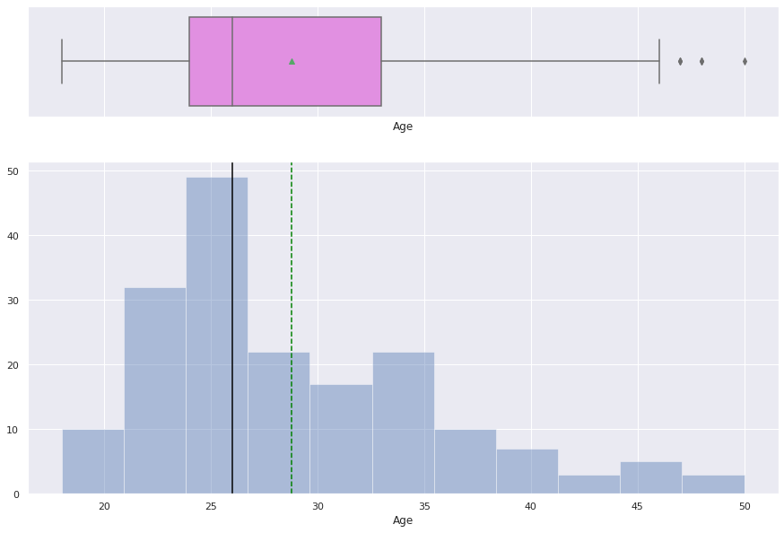

```python
histogram_boxplot(CGFPdf["Age"])
```

OBSERVATIONS ABOVE:

- The distribution of Age is right skewed.
- There are a outliers in this variable.
- From boxplot we can see that the third quartile(Q3) is equal to 33 which means 75% of customers are below the age of 33.

#### **Observations on Education.**

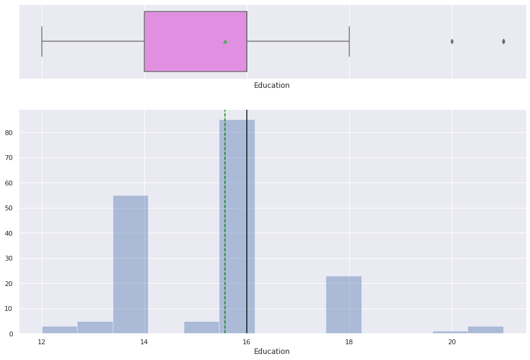

```python
histogram_boxplot(CGFPdf["Education"])
```

OBSERVATIONS ABOVE:

- Mean education for customers is 15.5 years.
- There are a few outliers present in data (customers who have education of more than 18 years).

#### **Observations on Usage.**

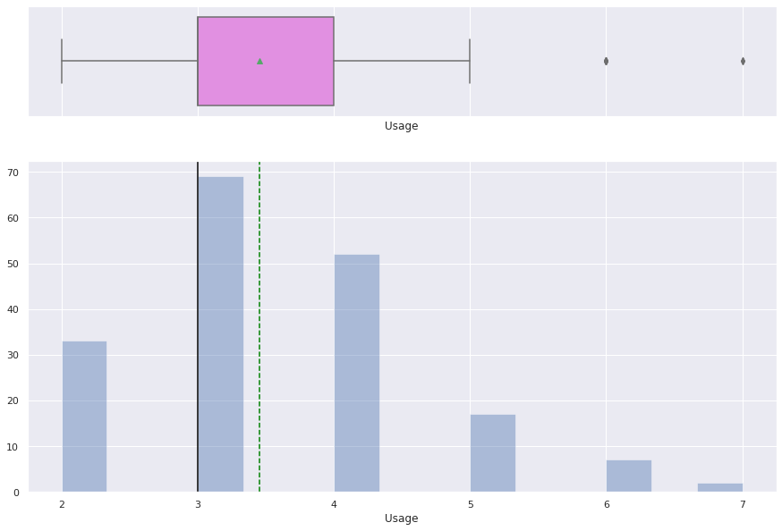

```python
histogram_boxplot(CGFPdf["Usage"])
```

OBSERVATIONS ABOVE:

- Customers want to use the treadmills 3-4 times a week on an average.
- There are few outliers, customers who wish to use treadmills 6-7 times a week.

#### **Observations on Income.**

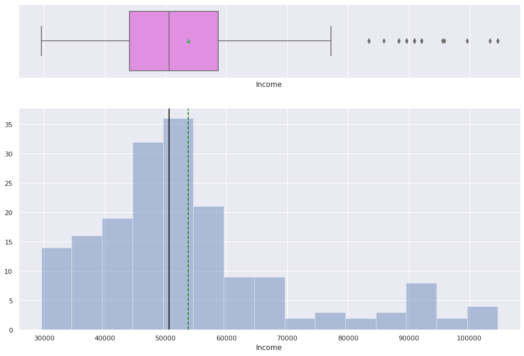

```python
histogram_boxplot(CGFPdf["Income"])
```

OBSERVATIONS ABOVE:

- Mean income of customers who bought treadmill is around 55000.
- Income is right skewed.
- It has many ouliers towards the higher end.

#### **Observations on Miles.**

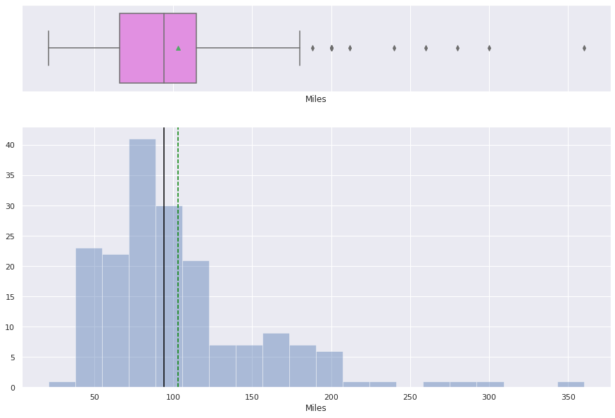

```python
histogram_boxplot(CGFPdf["Miles"])
```

OBSERVATIONS ABOVE:

- Most customers expect to run 100 miles per week.
- Miles is right skewed
- There are outliers present, some customers expect to run more than 200 miles per week, some customers wish to run more than 350 miles per week this could be an error in data collection or perhaps professional runners purchased the product.

```python
# Function to create barplots that indicate percentage for each category.

def perc_on_bar(plot, feature):
    '''
    plot
    feature: categorical feature
    the function won't work if a column is passed in hue parameter
    '''
    total = len(feature) # length of the column
    for p in ax.patches:
        percentage = '{:.1f}%'.format(100 * p.get_height()/total) # percentage of each class of the category
        x = p.get_x() + p.get_width() / 2 - 0.05 # width of the plot
        y = p.get_y() + p.get_height()           # hieght of the plot
        ax.annotate(percentage, (x, y), size = 12) # annotate the percantage
    plt.show() # show the plot
```

#### **Observations on Product.**

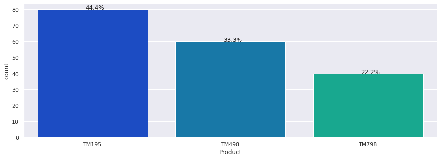

```python
plt.figure(figsize=(15,5))
ax = sns.countplot(CGFPdf["Product"],palette='winter')
perc_on_bar(ax,CGFPdf["Product"])
```

OBSERVATIONS ABOVE:

- The best selling product is TM195(44.4%), followed by TM498(33.3%), and TM798(22.2%).

#### **Observations on Gender.**

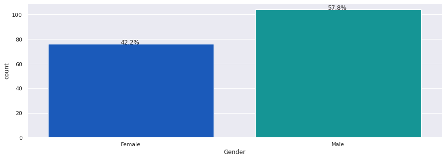

```python
plt.figure(figsize=(15,5))
ax = sns.countplot(CGFPdf["Gender"],palette='winter')
perc_on_bar(ax,CGFPdf["Gender"])
```

OBSERVATIONS ABOVE:

- There are more males customers(57.8%) than females(42.2%).

#### **Observations on Marital Status.**

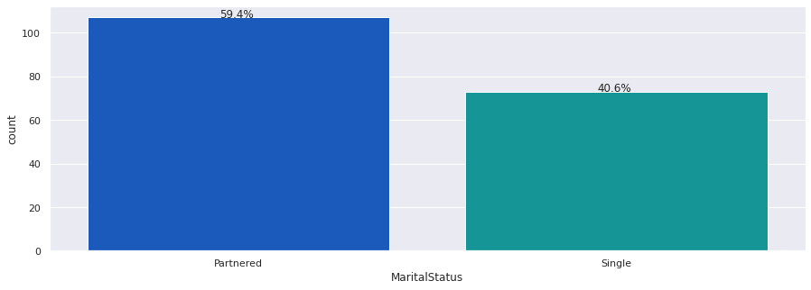

```python
plt.figure(figsize=(15,5))
ax = sns.countplot(CGFPdf["MaritalStatus"],palette='winter')
perc_on_bar(ax,CGFPdf["MaritalStatus"])
```

OBSERVATIONS ABOVE:

- 40.6% of customers are single while 59.4% of customers have a partner.

#### **Observations on Fitness.**

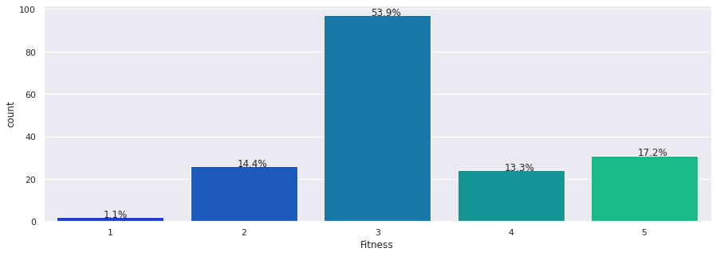

```python
plt.figure(figsize=(15,5))
ax = sns.countplot(CGFPdf["Fitness"],palette='winter')
perc_on_bar(ax,CGFPdf["Fitness"])
```

OBSERVATIONS ABOVE:

- 53.9% of the customers have rated them at 3 on a scale of 5 (1 being the least fit and 5 being the most fit),followed by 5 rating (17.2%).

#### **Observations on Education.**

- We saw earlier that years of education has a mean of 15.5 years of education, let us check what the proportion of each level of education among our customer population is.

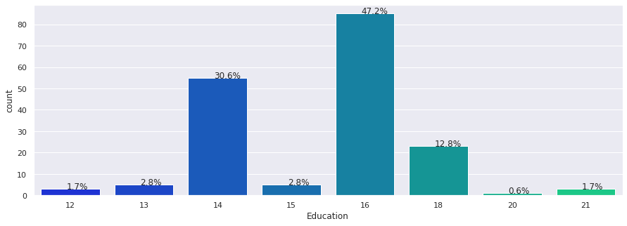

```python
plt.figure(figsize=(15,5))
ax = sns.countplot(CGFPdf["Education"],palette='winter')
perc_on_bar(ax,CGFPdf["Education"])
```

OBSERVATIONS ABOVE:

- 47.2% of customers have 16 years of education, followed by 14 years of education(30.6%).

#### **Observations on Usage.**

- We saw earlier that customers wish to use products for 3-4 days in a week, let's check what is the proportion of each level of usage among our customer population.

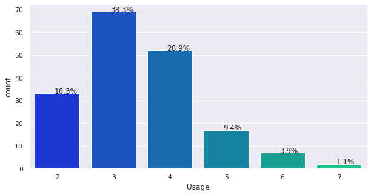

```python
plt.figure(figsize=(10,5))
ax = sns.countplot(CGFPdf["Usage"],palette='winter')
perc_on_bar(ax,CGFPdf["Usage"])
```

OBSERVATIONS ABOVE:

- 38.3% of customers wish to use the product 3 times a week followed by 28.9% customers who wish to use the product 4 times a week.

Let us look at the same variables with distribution plots, Kernel Density Estimation (kde) curves, and box plots.

```python
# Set the style of the seaborn visualization object
sns.set(style='darkgrid')
```

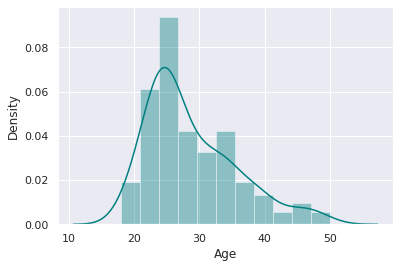

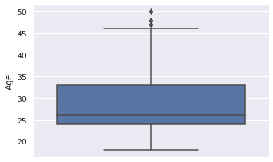

```python
# Age histogram and boxplot visualization:

sns.distplot(CGFPdf['Age'],color='teal')
plt.show()
sns.boxplot(y='Age',data=CGFPdf)
plt.show()
```

The age range of treadmill buyers is from 18 to 50. Looking at the boxplot, the middle 50% of treadmill buyers are 24 and 33 years old. 25% of buyers are 24 and 26 years old.

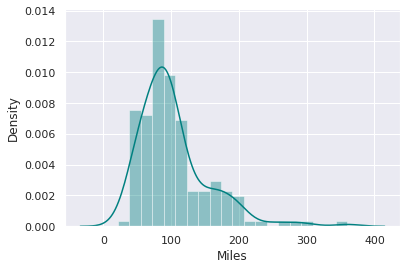

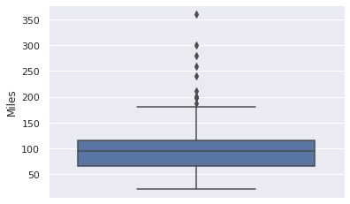

```python
# Miles histogram and boxplot visualization::

sns.distplot(CGFPdf['Miles'],color='teal')
plt.show()
sns.boxplot(y='Miles',data=CGFPdf)
plt.show()
```

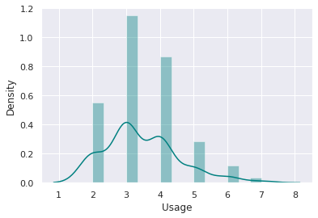

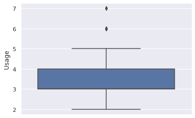

```python
# Usage histogram and boxplot visualization::

sns.distplot(CGFPdf['Usage'],color='teal')
plt.show()
sns.boxplot(y='Usage',data=CGFPdf)
plt.show()
```

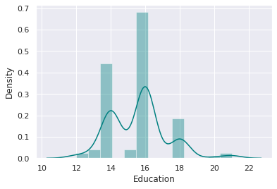

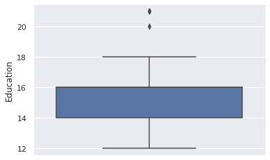

```python
# Education histogram and boxplot visualization::

sns.distplot(CGFPdf['Education'],color='teal')
plt.show()
sns.boxplot(y='Education',data=CGFPdf)
plt.show()
```

OBSERVATIONS ABOVE:

The Education boxplot shows that the middle 50% of treadmill customers have 14 to 16 years of education. The most common (the mode) declared number of years of education is 16 years. 16 years equates to roughly a Bachelor's college degree level of education.

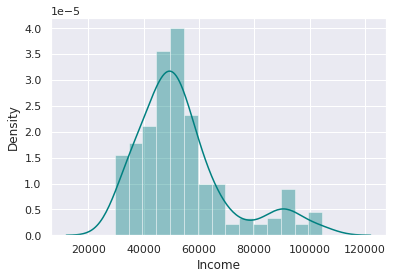

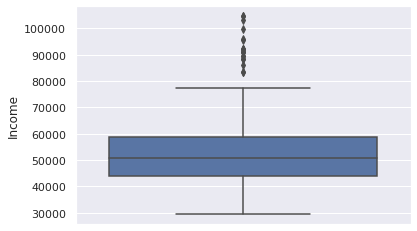

```python
# Income histogram and boxplot visualization:

sns.distplot(CGFPdf['Income'],color='teal')
plt.show()
sns.boxplot(y='Income',data=CGFPdf)
plt.show()
```

#### **Expected Miles Per Usage Per Customer.**

```python
# EXPECTED MILES PER USAGE PER CUSTOMER
# A new variable called [Miles Per Usage] = [Miles] divided by [Usage]

CGFPdf["Miles Per Usage"] = (CGFPdf["Miles"])/(CGFPdf["Usage"])
CGFPdf.head(15)
```

|  | Product | Age | Gender | Education | MaritalStatus | Usage | Fitness | Income | Miles | Miles Per Usage |
| --- | --- | --- | --- | --- | --- | --- | --- | --- | --- | --- |
| 0 | TM195 | 18 | Male | 14 | Single | 3 | 4 | 29562 | 112 | 37.333333 |
| 1 | TM195 | 19 | Male | 15 | Single | 2 | 3 | 31836 | 75 | 37.500000 |
| 2 | TM195 | 19 | Female | 14 | Partnered | 4 | 3 | 30699 | 66 | 16.500000 |
| 3 | TM195 | 19 | Male | 12 | Single | 3 | 3 | 32973 | 85 | 28.333333 |
| 4 | TM195 | 20 | Male | 13 | Partnered | 4 | 2 | 35247 | 47 | 11.750000 |
| 5 | TM195 | 20 | Female | 14 | Partnered | 3 | 3 | 32973 | 66 | 22.000000 |
| 6 | TM195 | 21 | Female | 14 | Partnered | 3 | 3 | 35247 | 75 | 25.000000 |
| 7 | TM195 | 21 | Male | 13 | Single | 3 | 3 | 32973 | 85 | 28.333333 |
| 8 | TM195 | 21 | Male | 15 | Single | 5 | 4 | 35247 | 141 | 28.200000 |
| 9 | TM195 | 21 | Female | 15 | Partnered | 2 | 3 | 37521 | 85 | 42.500000 |
| 10 | TM195 | 22 | Male | 14 | Single | 3 | 3 | 36384 | 85 | 28.333333 |
| 11 | TM195 | 22 | Female | 14 | Partnered | 3 | 2 | 35247 | 66 | 22.000000 |
| 12 | TM195 | 22 | Female | 16 | Single | 4 | 3 | 36384 | 75 | 18.750000 |
| 13 | TM195 | 22 | Female | 14 | Single | 3 | 3 | 35247 | 75 | 25.000000 |
| 14 | TM195 | 23 | Male | 16 | Partnered | 3 | 1 | 38658 | 47 | 15.666667 |

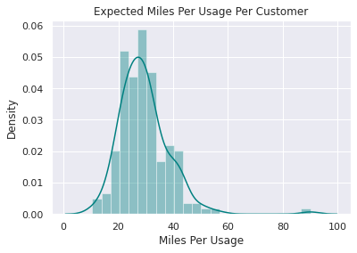

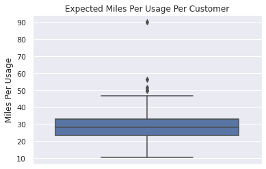

```python
# Miles Per Usage:

sns.distplot(CGFPdf['Miles Per Usage'],color='teal')
plt.title('Expected Miles Per Usage Per Customer')
plt.show()
sns.boxplot(y='Miles Per Usage',data=CGFPdf).set_title('Expected Miles Per Usage Per Customer')
plt.show()
```

### Bivariate Analysis.

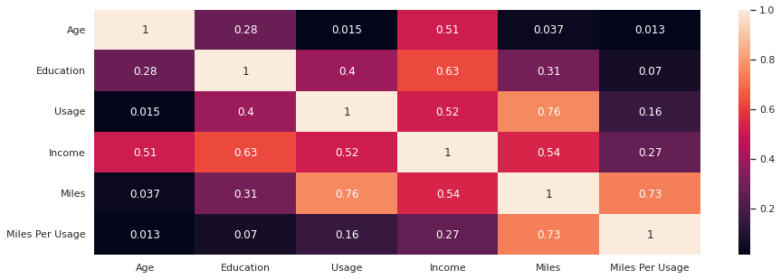

```python
plt.figure(figsize=(15,5))
sns.heatmap(CGFPdf.corr(),annot=True)
plt.show()
```

OBSERVATIONS ABOVE:

- Miles is highly correlated with Usage, a customer running more miles would mean he is also using the treadmill more.
- Education and Income has a positive correlation, indicating higher the education higher would be the income.
- Income shows a positive correlation with Age , Usage, and Miles.
- A positive correlation between age and income is expected but a high poistive correlation of income with usage and miles should be investigated further.

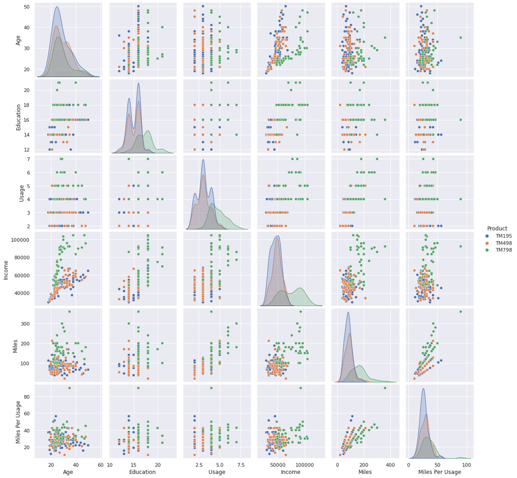

```python
sns.pairplot(data=CGFPdf.drop(["Fitness"],axis=1),hue="Product")
plt.show()
```

OBSERVATIONS ABOVE:

- We can see varying distributions in variables for different products, we should investigate further.

#### **Gender vs. Age.**

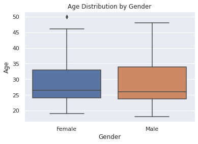

```python
# Let us compare Gender and Age in a boxplot display

sns.boxplot(x="Gender", y="Age", data=CGFPdf).set_title('Age Distribution by Gender');
```

#### **Product vs. Age.**

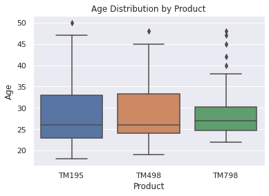

```python
# BIVARIATE ANALYSIS
# Let us compare Product and Age in a boxplot display

sns.boxplot(x="Product", y="Age", data=CGFPdf).set_title('Age Distribution by Product');
```

OBSERVATIONS ABOVE:

- TM195 and TM498 are preferred by customers of all ages but for TM798 customers are in the range of above 22 and below 38 (with some outliers).
- Model TM798 appeals to a narrower age range of customers, 22 years old to 38 years.

#### **Product vs. Education.**

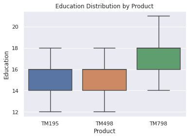

```python
# Let us compare Product and Education in a boxplot display

sns.boxplot(x="Product", y="Education", data=CGFPdf).set_title('Education Distribution by Product');
```

OBSERVATIONS ABOVE:

- Customers buying TM798 have higher education as compared to the customers buying the other two other products.
- Customers that purchased the TM798 model appear have more years of education (14 to 20+ years) compared to buyers of TM195 (12 to 18 years) and TM498 (12 to 18 years too).

#### **Product vs. Income.**

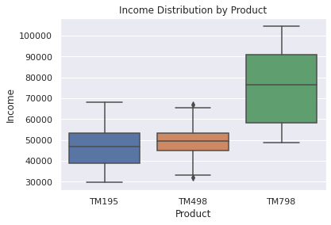

```python
# Let us compare Product and Income in a boxplot display

sns.boxplot(x="Product", y="Income", data=CGFPdf).set_title('Income Distribution by Product');
```

OBSERVATIONS ABOVE:

- Customers with higher income prefer TM798, whereas TM195 and TM498 are prefered by middle income customers.
- TM798 buyers have the highest median incomes at 75,000+ Dollars. This is approximately 50% more than the customers of TM195 (median approx. 45,000+ Dollars) and TM498 (median approx. 50,000 Dollars).
- The income range for TM798 customers is also higher ranging from 49,000 Dollars to 105,000 Dollars; in comparison the income range of TM195 and tm498 is 30,000 Dollars to 68,000 Dollars.

#### **Product vs. Usage.**

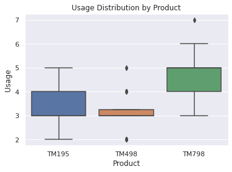

```python
# Let us compare Product and Usage in a boxplot display

sns.boxplot(x="Product", y="Usage", data=CGFPdf).set_title('Usage Distribution by Product');
```

OBSERVATIONS ABOVE:

- Customers who have higher expected treadmill usage(greater than 3 days) prefer the TM798 product, Customers with very light(2-3 days) usage prefer TM498, customers who have moderate usage (greater than 2 days but less than or equal to 5 days) prefer TM195.
- Buyers of TM798 expect tO be the heaviest users of of their treadmilss compared to customers of TM196 and TM498. Their goal is to use the treadmill 3 to 6 times a week with a median of 5 times a week.
- In comparison, buyers of TM195 and TM498 expect to use their treadmills between 2 to 5 times and 3 to 4 times respectively, with expected medians of 3 times a week.

#### **Product vs. Fitness**

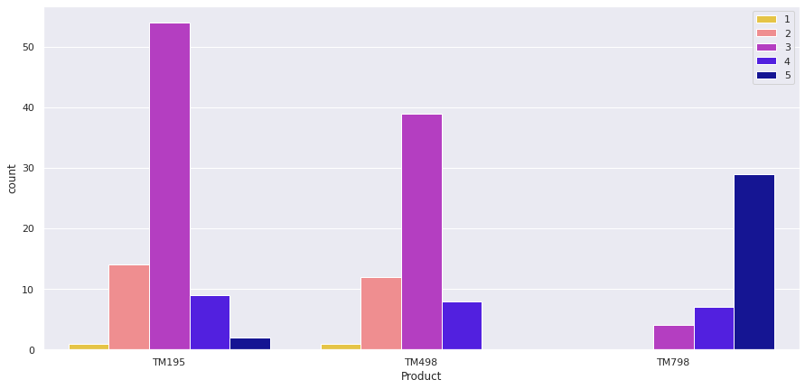

```python
# Let us compare Product and Fitness in a boxplot display

# sns.boxplot(x="Product", y="Fitness", data=CGFPdf).set_title('Fitness Distribution by Product');

plt.figure(figsize=(15,7))
sns.countplot(CGFPdf["Product"],hue=CGFPdf["Fitness"],palette="gnuplot2_r")
plt.legend(bbox_to_anchor=(1.00, 1))
plt.show()
```

OBSERVATIONS ABOVE:

- Customers who purchased TM195 and TM498 gave themselves a balanced fitness rating of 3 (on a scale of 1 to 5, 1 being the least fit and 5 being the most fit), but for TM798 most of customers have rated themselves higher in fitness that is 5.
- TM798 treadmill customers rate their fitness levels more highly than the other 2 models.
- The median fitness rating for TM798 is 5, the highest a customer can rate themselves.
- TM195 and TM498 treadmill customers have a median fitness level rating of 3.